# OCR+ECAR-Pipeline

HOW TO USE

Wells removed. Out od 140-160 mmHg interval

| Plate | N_out | Wells |
| --- | --- | --- |
| CON-BIS-HF-1 14-08-2017 | 49 | A07 A08 A09 A10 A11 A12 B07 B08 B09 B10 B11 B12 C05 C07 C08 C09 C10 C11 C12 D07 D08 D09 D10 D11 D12 E07 E08 E09 E10 E11 E12 F07 F08 F09 F10 F11 F12 G07 G08 G09 G10 G11 G12 H07 H08 H09 H10 H11 H12 |
| PBMC-HF#1B 02-10-2017 | 17 | A03 A09 B08 C06 C12 E03 E10 E12 F02 F09 F10 F11 F12 G03 H04 H08 H09 |
| PBMC-HF#3A+HF#3Ab 28-08-2017 | 0 |  |
| PBMC-HF#3B+HC#2 17-10-2017 | 79 | A01 A03 A05 A06 A07 A08 A09 A10 A11 B03 B04 B05 B06 B07 B08 B09 B10 B11 B12 C01 C02 C03 C04 C05 C06 C07 C08 C09 C10 C11 C12 D03 D04 D05 D06 D07 D08 D09 D10 D12 E01 E02 E03 E04 E05 E06 E07 E08 E09 E10 … |
| PBMC-HF#4A+HF#4Ab 25-09-2017 | 6 | A12 B09 C06 D07 E09 H01 |
| PBMC-DB2#9A_2+HF#31A 13-08-2018 | 7 | B07 C06 D06 D07 E06 F09 G06 |
| PBMC-DB2#9A_2+HF#31A 13-08-2018 | 7 | B07 C06 D06 D07 E06 F09 G06 |
| CON-BIS-HF-1 14-08-2017 | 49 | A07 A08 A09 A10 A11 A12 B07 B08 B09 B10 B11 B12 C05 C07 C08 C09 C10 C11 C12 D07 D08 D09 D10 D11 D12 E07 E08 E09 E10 E11 E12 F07 F08 F09 F10 F11 F12 G07 G08 G09 G10 G11 G12 H07 H08 H09 H10 H11 H12 |
| PBMC-HF#1B 02-10-2017 | 17 | A03 A09 B08 C06 C12 E03 E10 E12 F02 F09 F10 F11 F12 G03 H04 H08 H09 |

Background measurements not included in OCR correction

| Plate | N_out | Wells | Measurement |
| --- | --- | --- | --- |
| CON-BIS-HF-1 14-08-2017 | 0 |  |  |
| PBMC-HF#1B 02-10-2017 | 2 | H01 H12 | 1 1 |
| PBMC-HF#3A+HF#3Ab 28-08-2017 | 2 | A01 A12 | 1 5 |
| PBMC-HF#3B+HC#2 17-10-2017 | 0 |  |  |
| PBMC-HF#4A+HF#4Ab 25-09-2017 | 5 | A12 D07 | 1 2 8 8 9 |
| PBMC-DB2#9A_2+HF#31A 13-08-2018 | 18 | D06 D07 | 1 1 2 2 3 3 4 4 5 5 6 6 7 7 8 8 9 9 |
| PBMC-DB2#9A_2+HF#31A 13-08-2018 | 18 | D06 D07 | 1 1 2 2 3 3 4 4 5 5 6 6 7 7 8 8 9 9 |
| CON-BIS-HF-1 14-08-2017 | 0 |  |  |
| PBMC-HF#1B 02-10-2017 | 2 | H01 H12 | 1 1 |

Background measurements not included in ECAR correction

| Plate | N_out | Wells | Measurement |
| --- | --- | --- | --- |
| CON-BIS-HF-1 14-08-2017 | 5 | A12 H12 | 1 2 2 3 3 |
| PBMC-HF#1B 02-10-2017 | 0 |  |  |
| PBMC-HF#3A+HF#3Ab 28-08-2017 | 1 | A12 | 5 |
| PBMC-HF#3B+HC#2 17-10-2017 | 9 | H12 | 1 2 3 4 5 6 7 8 9 |
| PBMC-HF#4A+HF#4Ab 25-09-2017 | 6 | A12 D06 D07 | 1 2 7 7 8 9 |
| PBMC-DB2#9A_2+HF#31A 13-08-2018 | 4 | H12 D06 | 1 2 3 6 |
| PBMC-DB2#9A_2+HF#31A 13-08-2018 | 4 | H12 D06 | 1 2 3 6 |
| CON-BIS-HF-1 14-08-2017 | 5 | A12 H12 | 1 2 2 3 3 |
| PBMC-HF#1B 02-10-2017 | 0 |  |  |

## ———– OCR ———–

# Filter out no relevant samples

```
## [1] "Samples removed due lack of usable measurements(less than 8  in any interval)"
```

```
## [1] "2-HC | 17-10-2017"  "3B-HF | 17-10-2017"
```

```
## [1] "Samples removed because there are no 4 intervals )"
```

```
## [1] "2-HC | 17-10-2017"
```

# Identyfy Outliars

Removed outliars in each iteration:

```
## 1  Point outliares:  192 -- 4.676084 %
## 2  Point outliares:  52 -- 1.266439 %
## 3  Point outliares:  17 -- 0.4140283 %
## 4  Point outliares:  2 -- 0.04870921 %
## 5  Point outliares:  0 -- 0 %
## Total single point outliars:  6.405261 %
```

Amount of removed outliers across samples

| sample_id | percentage |
| --- | --- |
| 4Ab-HF \| 25-09-2017 | 11.11 % |
| 3A-HF \| 28-08-2017 | 10.83 % |
| 3Ab-HF \| 28-08-2017 | 10.00 % |
| 1B- \| 02-10-2017 | 4.81 % |
| 9A_2-DB2 \| 13-08-2018 | 3.32 % |
| 31A-HF \| 13-08-2018 | 2.68 % |
| 4A-HF \| 25-09-2017 | 1.69 % |
| 1A-HF \| 14-08-2017 | 0.57 % |

# Print schemes of removed points for all samples

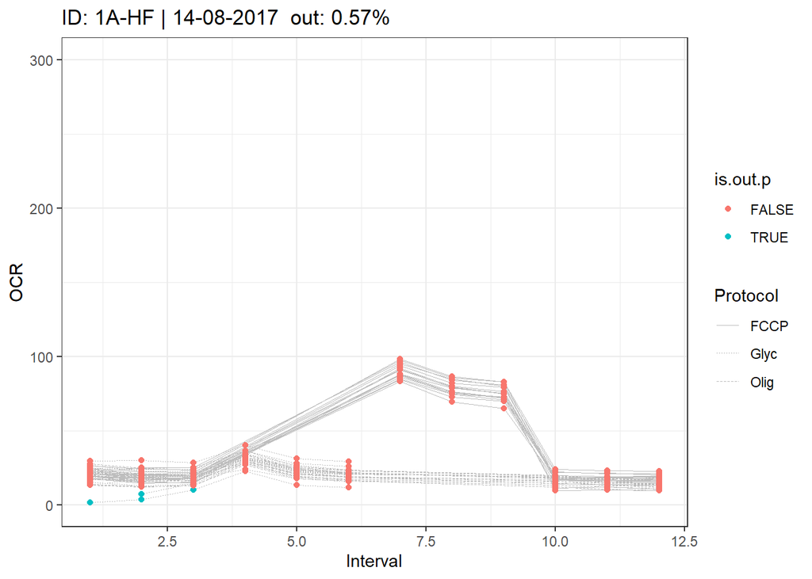

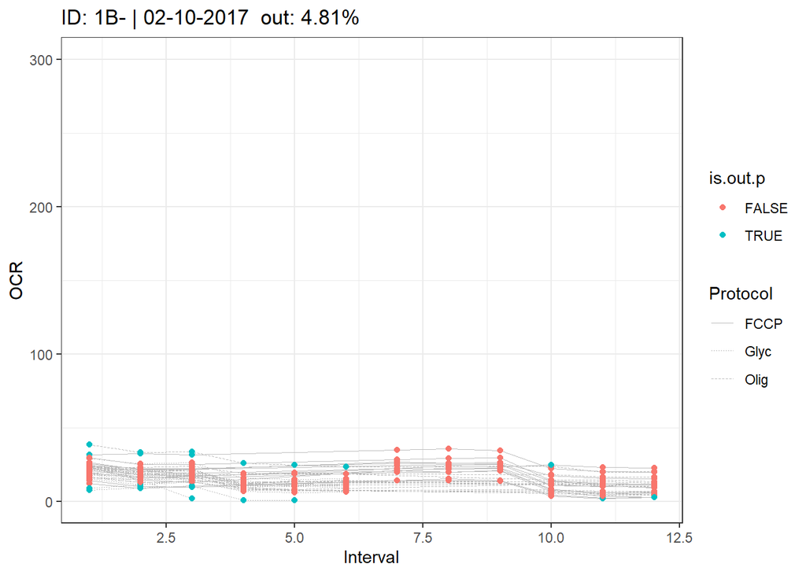

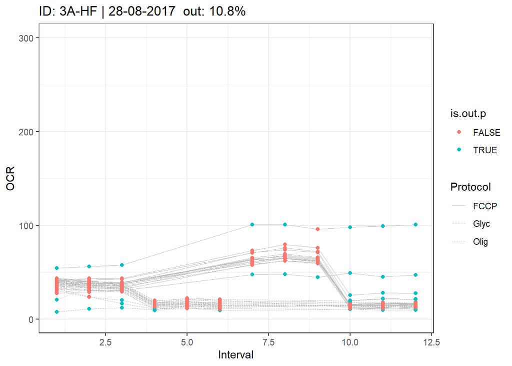

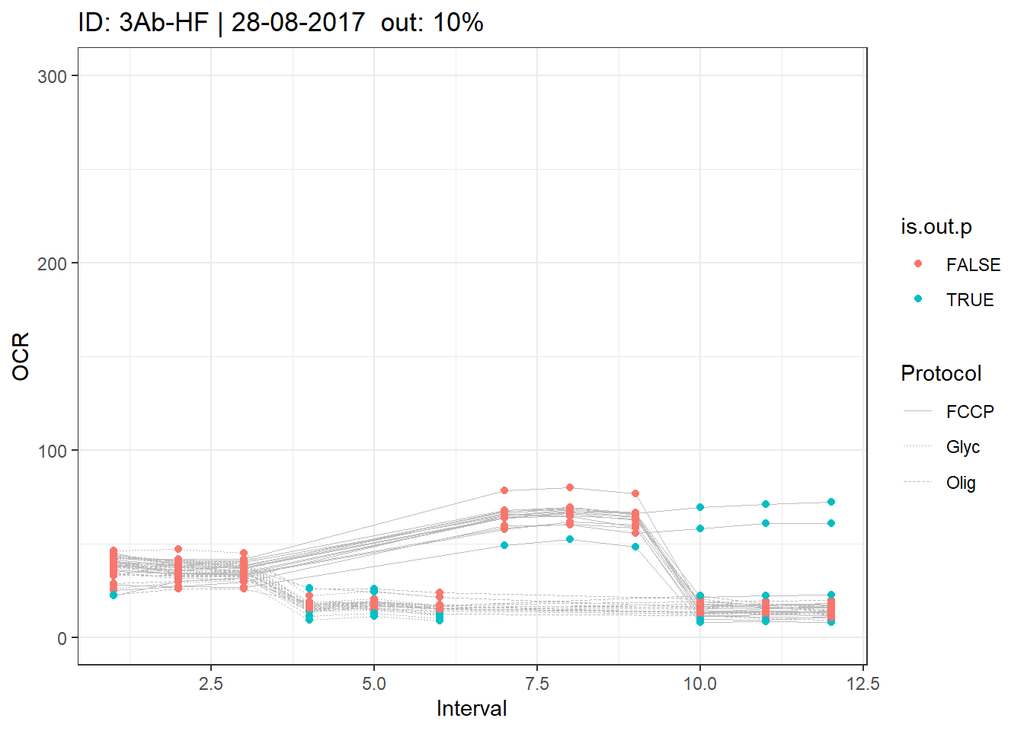

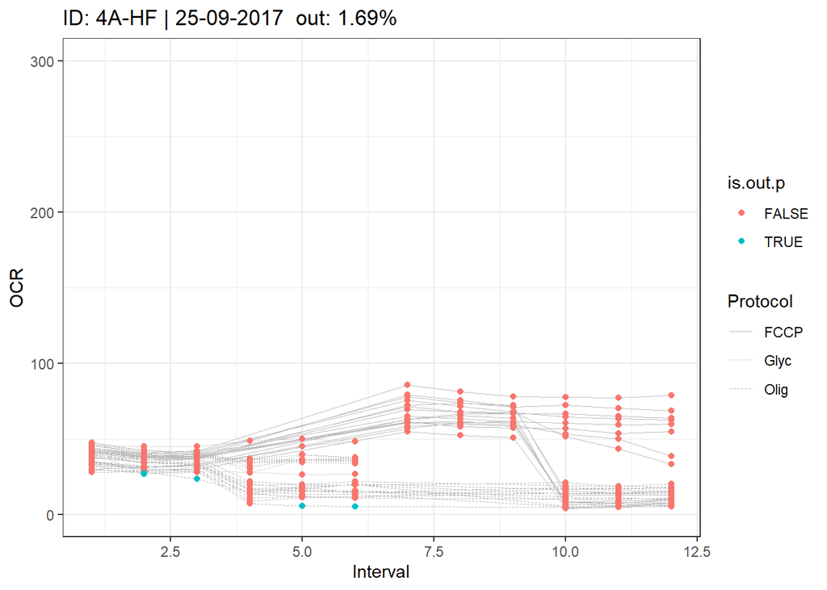

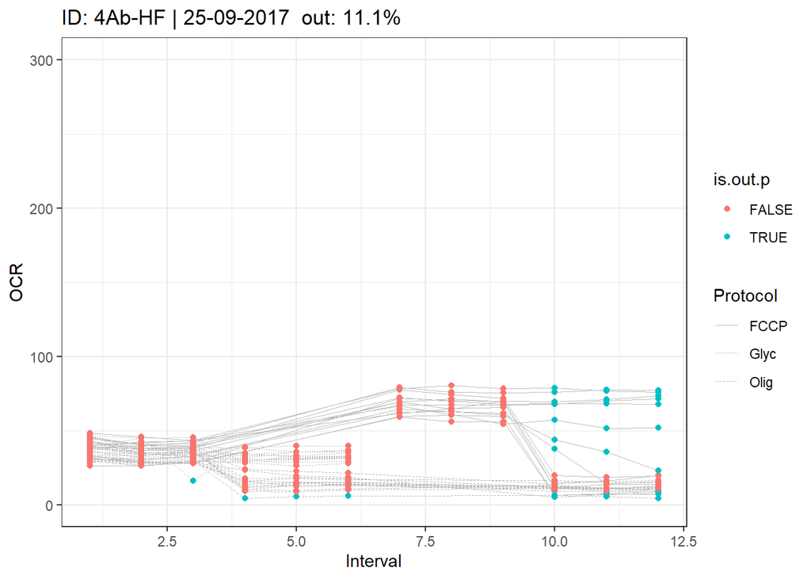

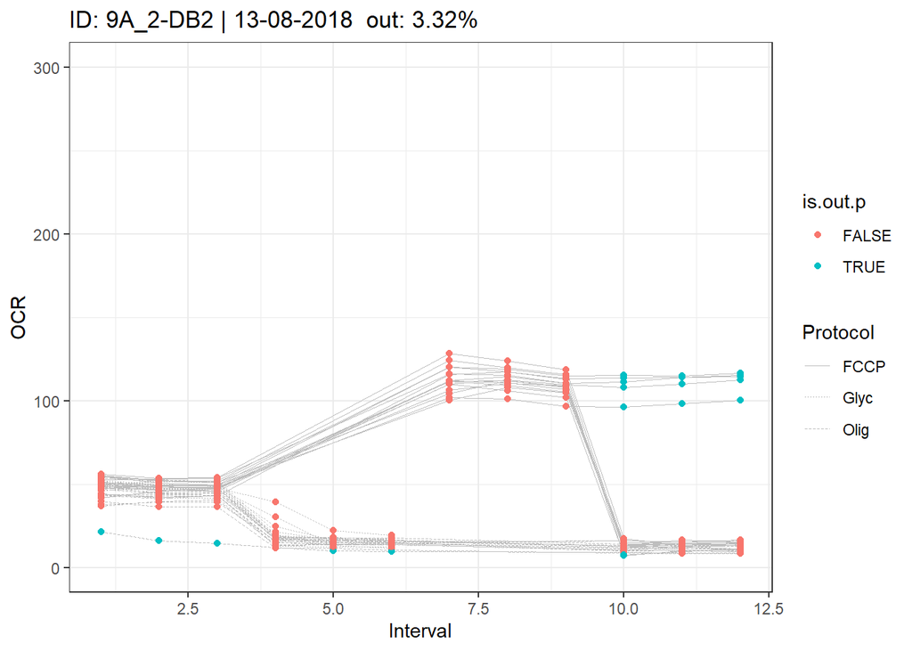

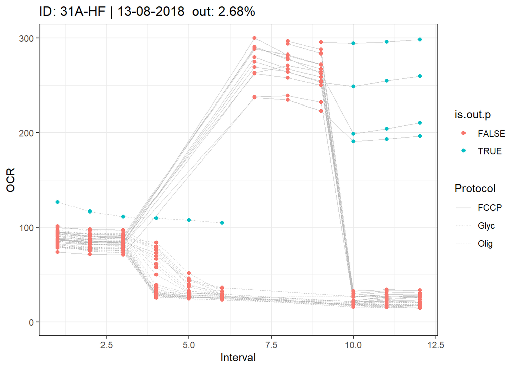

# Get Estimates

## Bioenergetics and Estimates

# Estimates

If you want to see or change how they are computed see the function compute_bioenergetics_ ()in file analysis_source_functions.R

Example of estimates file

| sample_id | Interval | mean | SD | SE | size | CV |
| --- | --- | --- | --- | --- | --- | --- |
| 1A-HF \| 14-08-2017 | Int1 | 18.888 | 3.566 | 0.158 | 508 | 18.879 |
| 1A-HF \| 14-08-2017 | Int2 | 23.557 | 5.890 | 0.321 | 336 | 25.002 |
| 1A-HF \| 14-08-2017 | Int3 | 80.429 | 8.067 | 0.582 | 192 | 10.030 |
| 1A-HF \| 14-08-2017 | Int4 | 16.807 | 3.196 | 0.168 | 360 | 19.014 |

See diferent distribution of the estimates

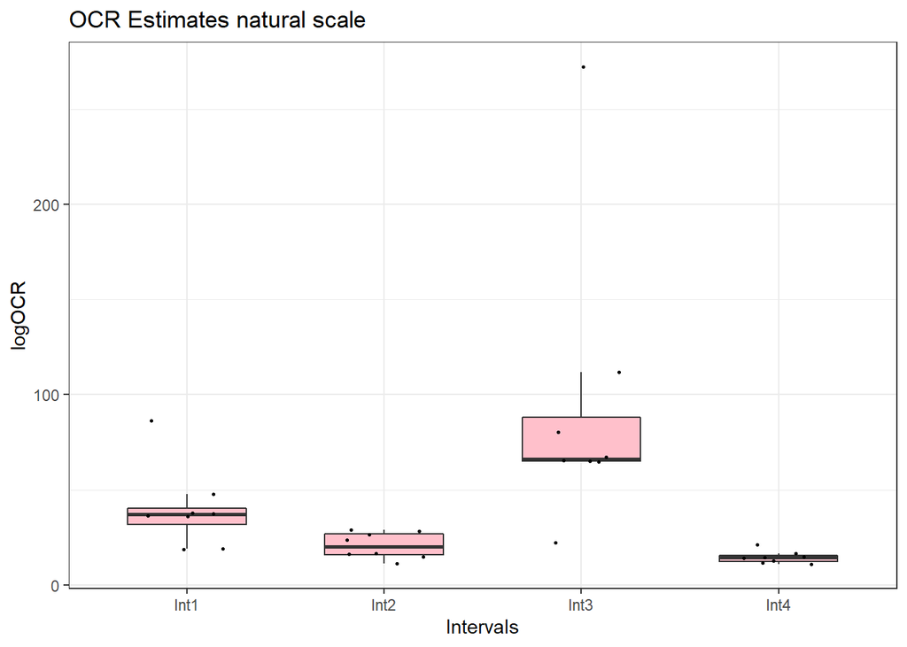

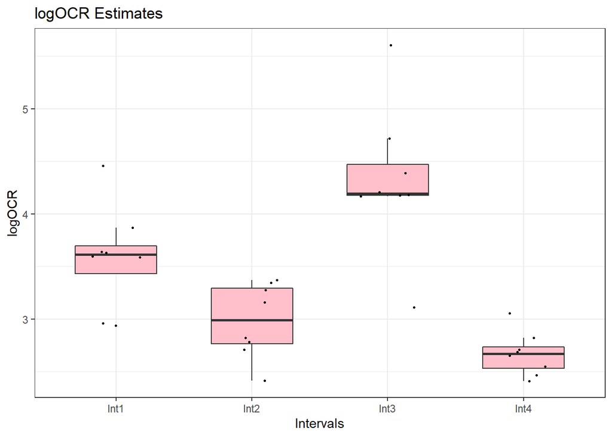

See diferent distribution of the estimates

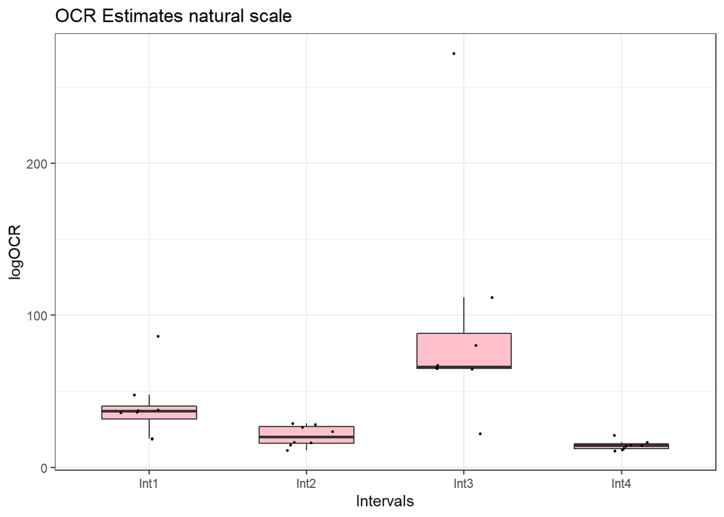

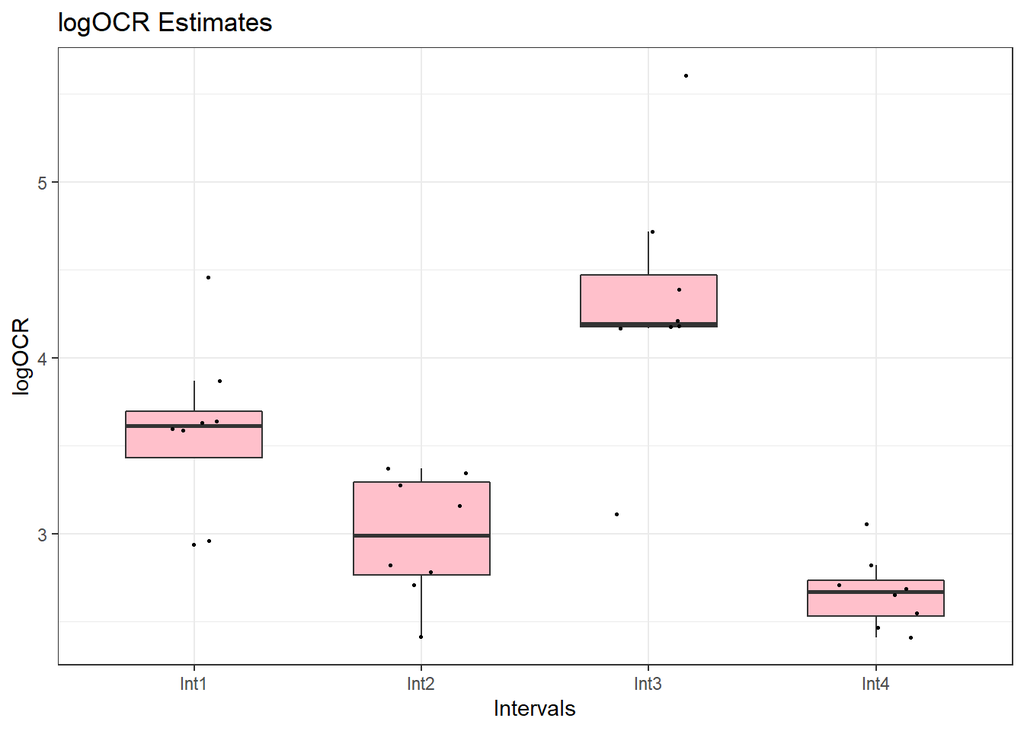

# Bioenergetics

Bioenergetics are computed from estimates, there there are two sets of bioenergetics provided.

1. Ratio Based, computed from log(OCR) estimates Located in OUTPUT/LogOCR-BioEnergetics.csv
2. Difference based, computed from OCR esimates Located in OUTPUT/OCR-BioEnergetics.csv If you want to see or change how they are computed see the function compute_bioenergetics_() in file analysis_source_functions.R

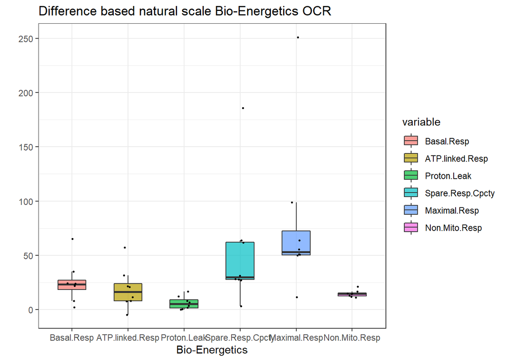

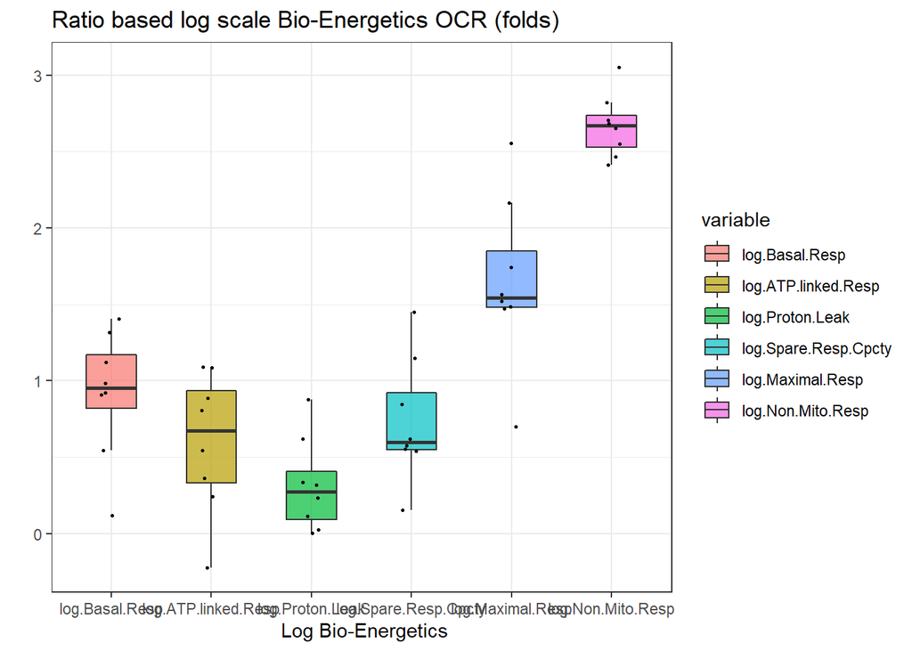

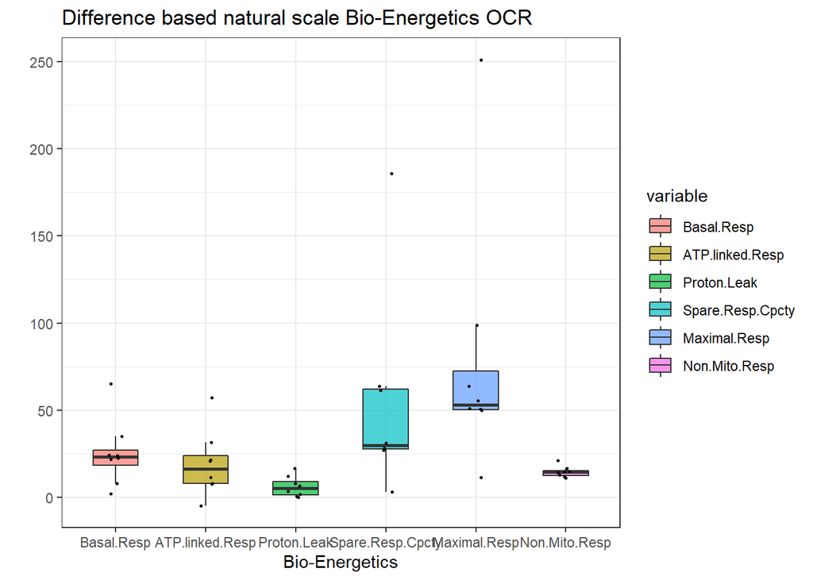

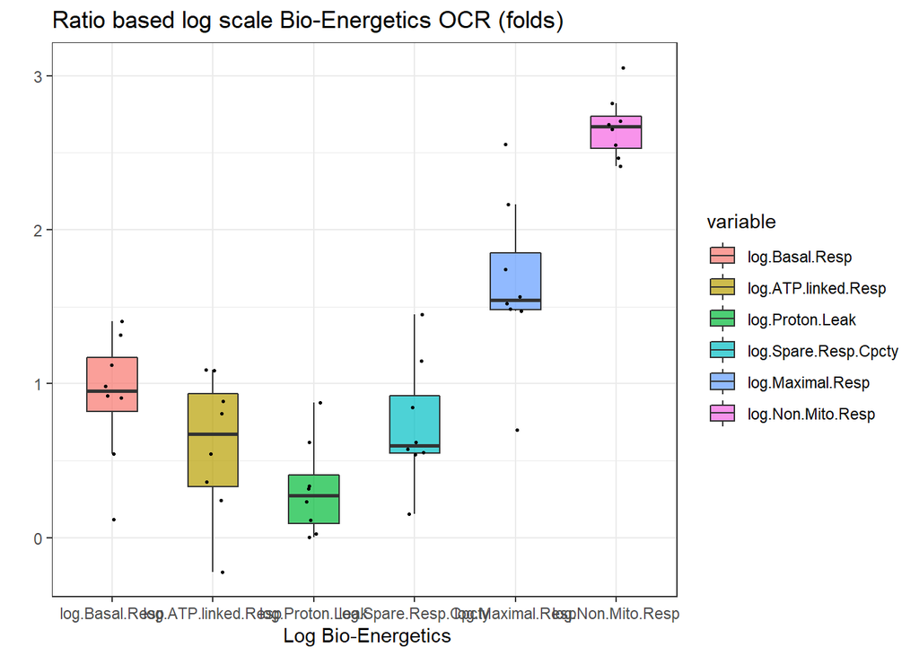

Example of Bioenergetics file

| Sample | variable | value |
| --- | --- | --- |
| 1A-HF \| 14-08-2017 | log.Basal.Resp | 0.117 |
| 1B- \| 02-10-2017 | log.Basal.Resp | 0.546 |
| 31A-HF \| 13-08-2018 | log.Basal.Resp | 1.405 |
| 3A-HF \| 28-08-2017 | log.Basal.Resp | 0.911 |

# Groups

If the sample_id of your samples contains letters A or B following graph will plot bioenergetics of the two grups. It is suggested to use this plot only when you are looking at grouped samples and project name shouldn’t contain letters A or B. Any sample that is not labeled will be part of B group.

You can change the A and B letters in the markdown code to compare other groups.

```r
# difference based BE
n.bio %>%
  mutate(Group = ifelse(grepl("A", Sample), "A", "B")) %>% # change "A" and "B" for any character or string
  ggplot(aes(Group, value, fill = variable))+
  ggtitle("OCR Normal scale Bio-Energetics biological groups ")+
  geom_boxplot(width = 0.5, outlier.size = -1, alpha = 0.7)+
  geom_jitter(width = 0.1, show.legend = FALSE, size = 0.5)+
  xlab("Bio-Energetics")+
  ylab("OCR")+
  facet_grid(. ~ variable ) +
  theme_bw()
```

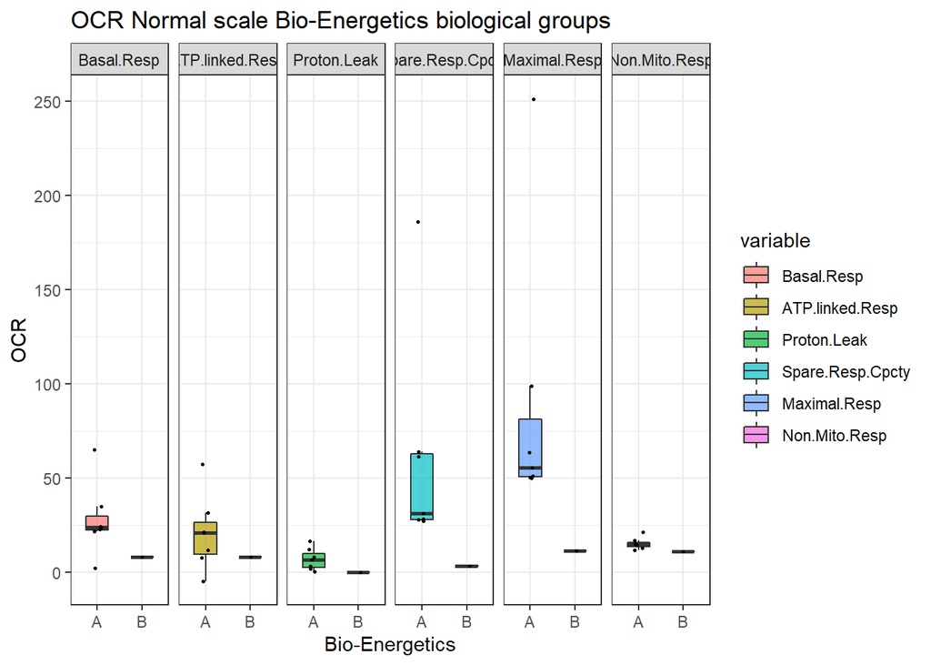

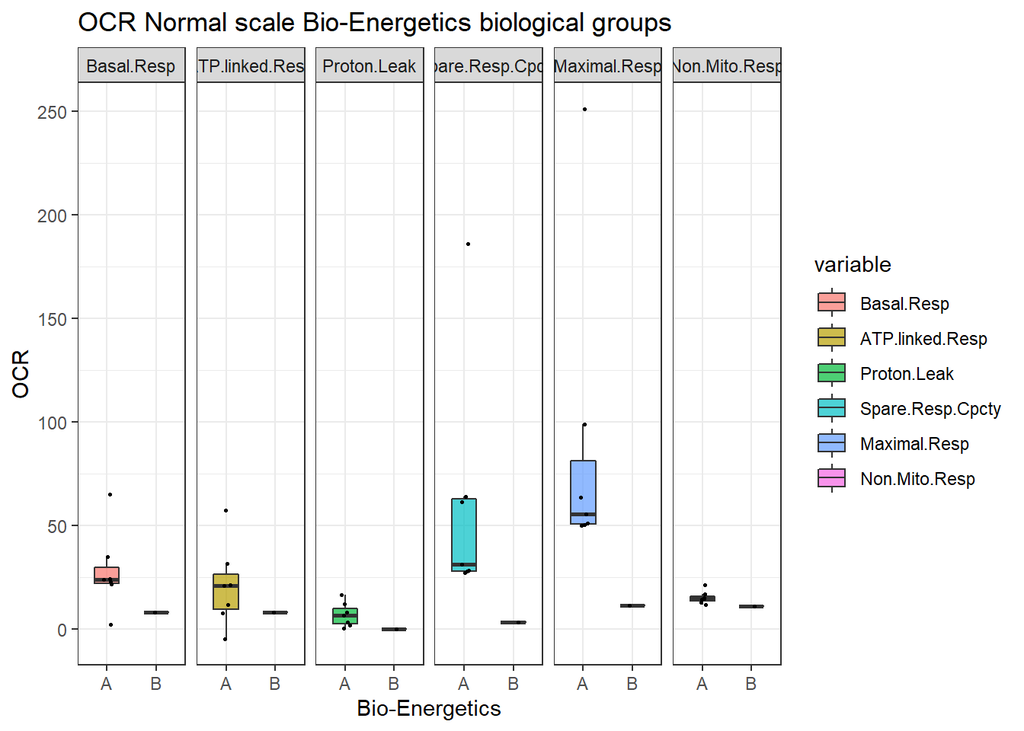

```r
# ratio based BE
l.bio %>%
  mutate(Group = ifelse(grepl("A", Sample), "A", "B")) %>% # change "A" and "B" for any character or string
  ggplot(aes(Group, value, fill = variable))+
  ggtitle("OCR Normal scale Bio-Energetics biological groups ")+
  geom_boxplot(width = 0.5, outlier.size = -1, alpha = 0.7)+
  geom_jitter(width = 0.1, show.legend = FALSE, size = 0.5)+
  xlab("Bio-Energetics")+
  ylab("OCR")+
  facet_grid(. ~ variable ) +
  theme_bw()
```

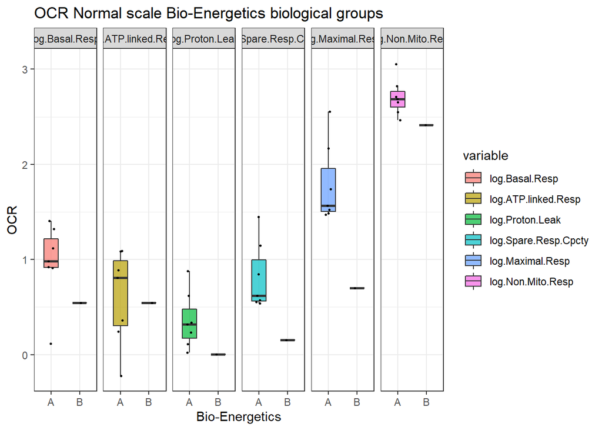

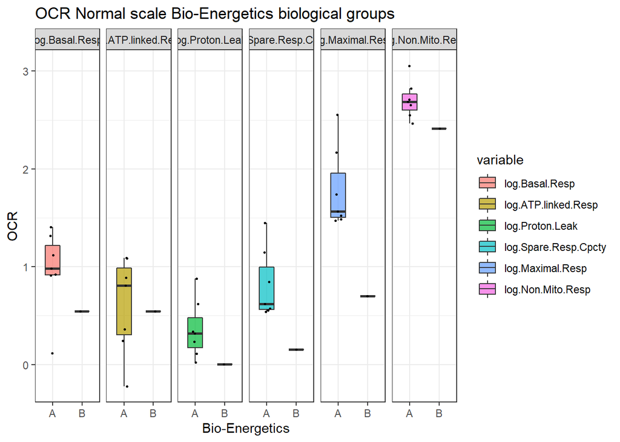

## ———— ECAR ————

# Filter out no relevant samples

```
## [1] "Samples removed due lack of usable measurements(less than 8  in any interval)"
```

```
## [1] "2-HC | 17-10-2017"
```

```
## [1] "Samples removed because don't have 3 Intervals"
```

```
## [1] "3B-HF | 17-10-2017"
```

# Remove outliars

```
## 1  Point outliares:  102 -- 3.568929 %
## 2  Point outliares:  48 -- 1.679496 %
## 3  Point outliares:  37 -- 1.294612 %
## 4  Point outliares:  23 -- 0.8047586 %
## 5  Point outliares:  7 -- 0.2449265 %
## 6  Point outliares:  9 -- 0.3149055 %
## 7  Point outliares:  18 -- 0.6298111 %
## 8  Point outliares:  20 -- 0.6997901 %
## 9  Point outliares:  32 -- 1.119664 %
## 10  Point outliares:  16 -- 0.5598321 %
## 11  Point outliares:  12 -- 0.419874 %
## 12  Point outliares:  6 -- 0.209937 %
## 13  Point outliares:  0 -- 0 %
## Total single point outliars:  11.54654 %
```

Amount of removed outliers across samples

| sample_id | percentage |
| --- | --- |
| 1A-HF \| 14-08-2017 | 24.30 % |
| 3A-HF \| 28-08-2017 | 16.67 % |
| 3Ab-HF \| 28-08-2017 | 15.08 % |
| 1B- \| 02-10-2017 | 4.02 % |
| 4A-HF \| 25-09-2017 | 1.64 % |
| 31A-HF \| 13-08-2018 | 1.47 % |
| 9A_2-DB2 \| 13-08-2018 | 0.88 % |

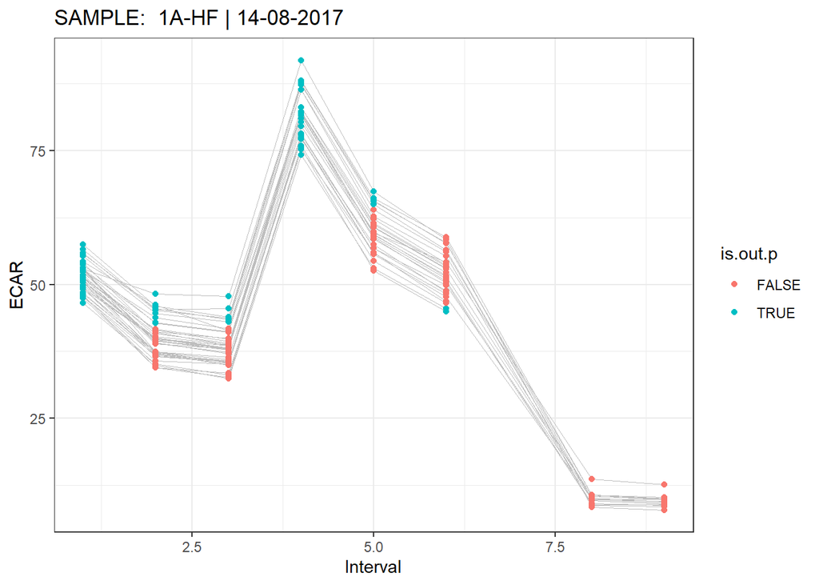

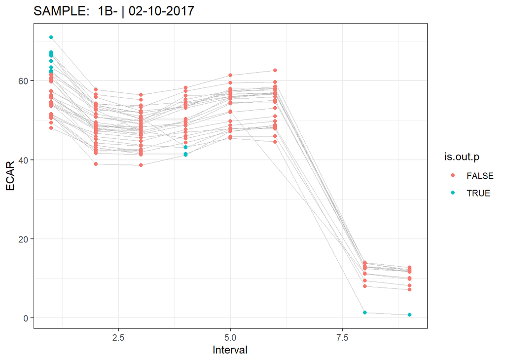

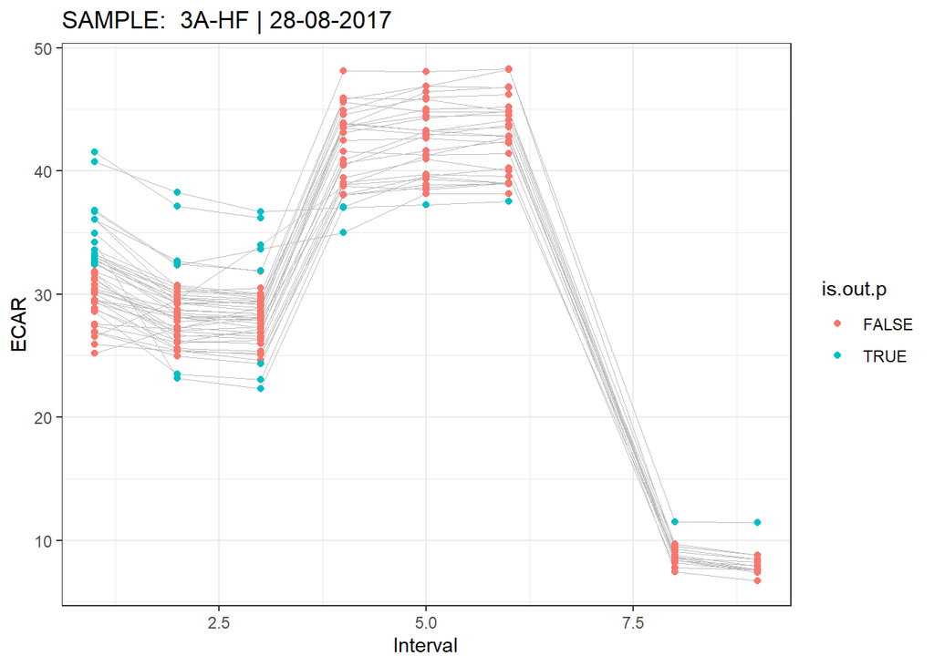

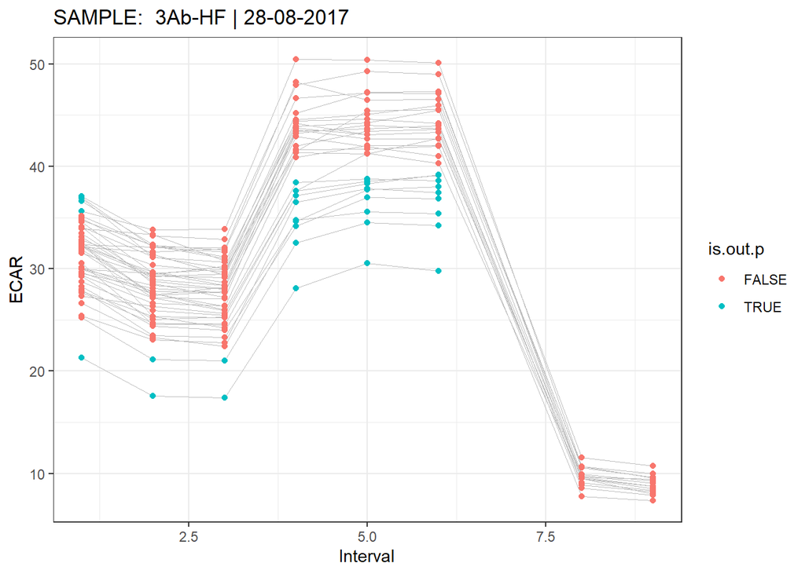

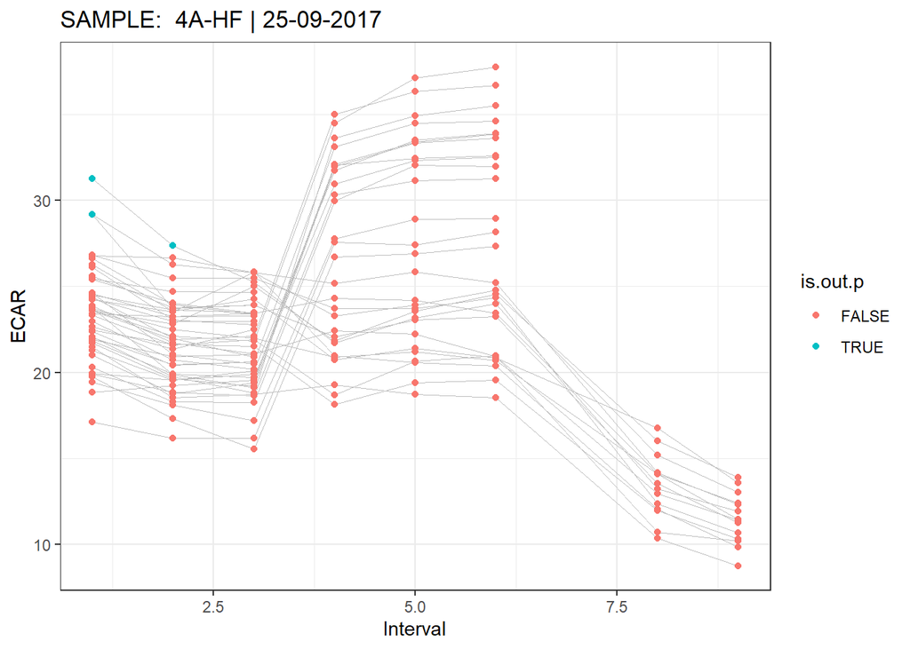

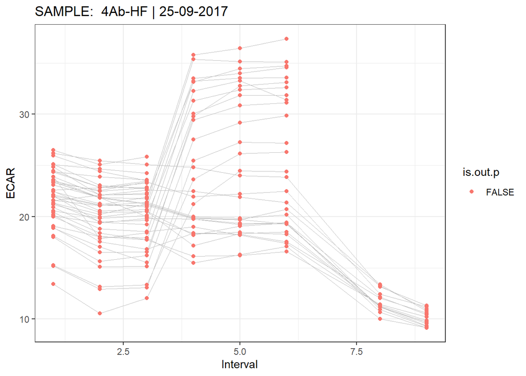

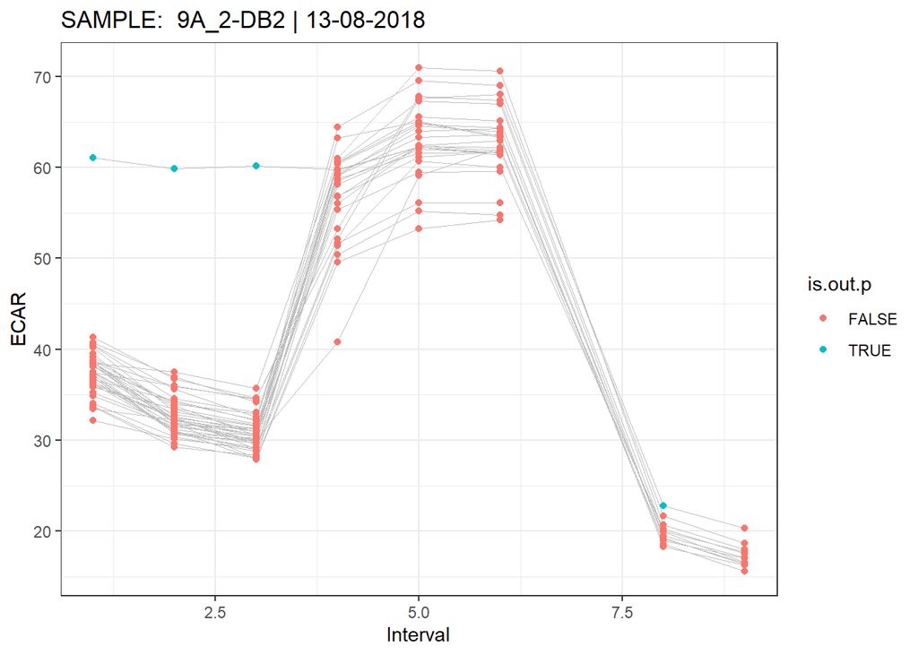

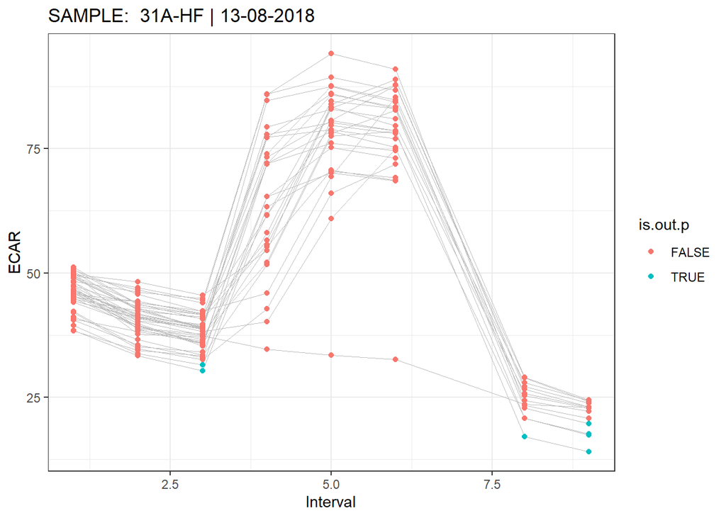

# Estimates

## Bioenergetics and Estimates

#Estimates

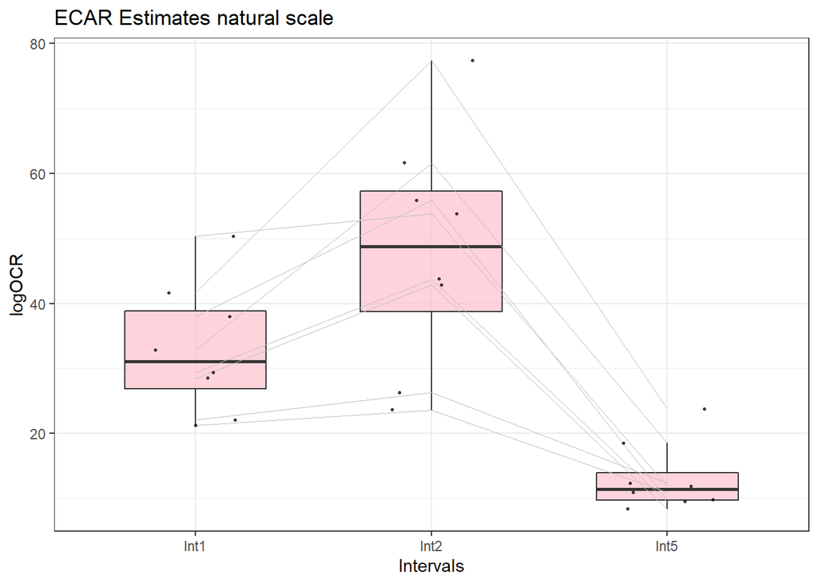

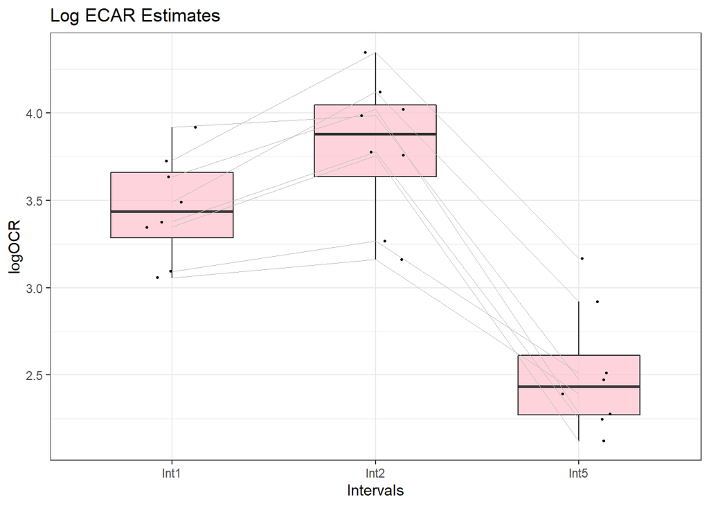

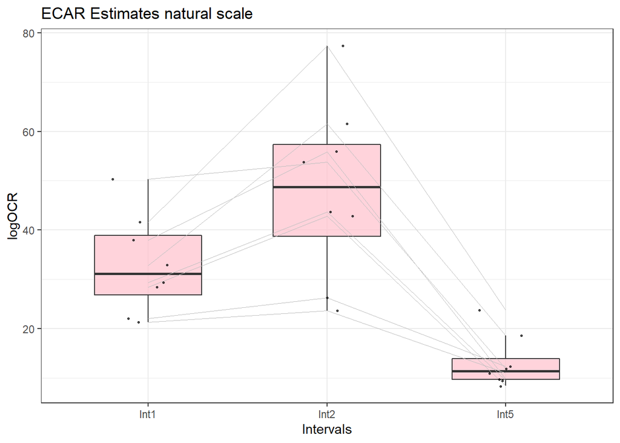

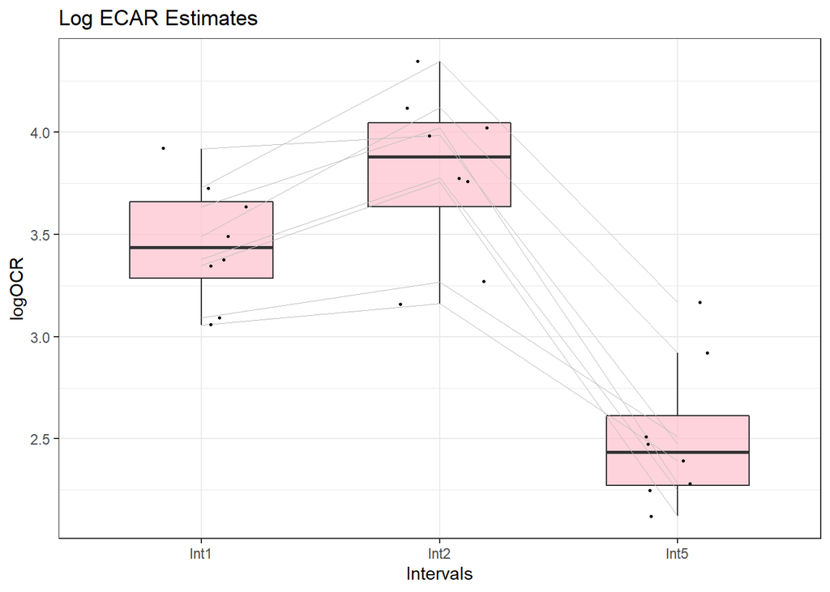